## Packages

```r
library(dplyr)
library(lubridate)
library(ggplot2)
```

## Loading and preprocessing the data

As a first step, we have to `unzip()` the zip file ‘activity.zip’. After unzipping, we can look at the data in the folder with the `dir()` command.

```r
unzip("activity.zip")
dir()
```

```
## [1] "activity.csv"           "activity.zip"           "Course project 1.Rproj"
## [4] "PA1_Template.html"      "PA1_Template.rmd"
```

Now, we can load the data from the csv file ‘activity.csv’ into the `data.frame` raw. After loading the data, we have a first look at the data.

```r
df_raw <- read.csv("activity.csv")
head(df_raw)
```

```
##   steps       date interval
## 1    NA 2012-10-01        0
## 2    NA 2012-10-01        5
## 3    NA 2012-10-01       10
## 4    NA 2012-10-01       15
## 5    NA 2012-10-01       20
## 6    NA 2012-10-01       25
```

We note that there are missing values in the column steps. The date column still needs to be transformed into a date format. We call the processed data.frame dfm (*m* for missing values).

```r
dfm <- df_raw %>%
    mutate(date = ymd(date))
```

## Mean total number of steps taken per day

In order to calculate the total number of steps per day, we have to aggregate the data by day (sum over all intervals of a given day). We do this by grouping over date and summing up the steps. Note that since `steps` includes missing values, we have to use the option `na.rm = TRUE` when summing.

We call the daily data frame dfm_daily.

```r
dfm_daily <- dfm %>%
    group_by(date) %>%
    summarise(totalsteps = sum(steps, na.rm = TRUE))
```

Now we make a histogram of the total steps per day.

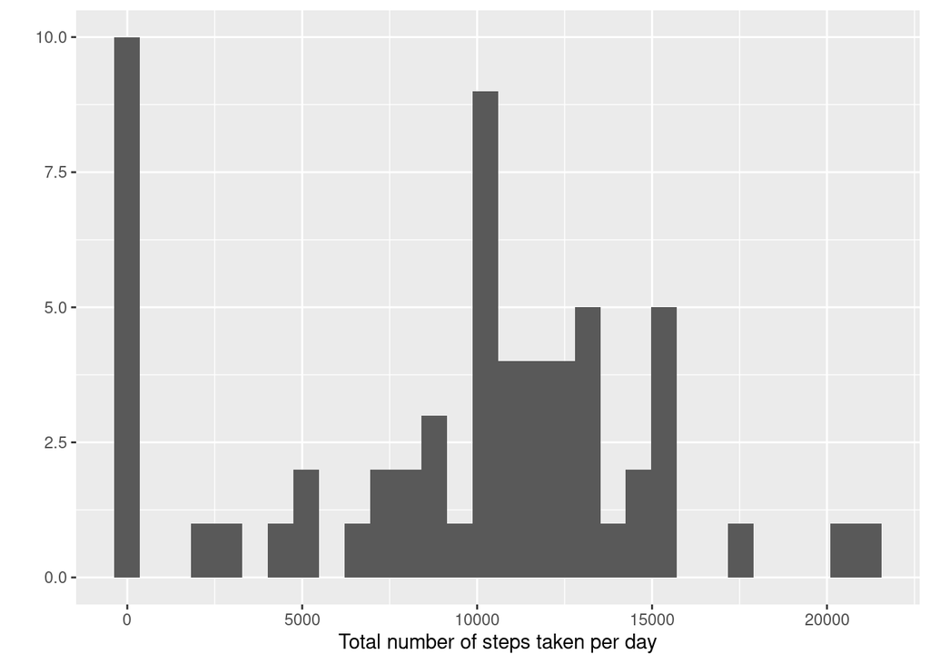

```r
qplot(dfm_daily$totalsteps, xlab="Total number of steps taken per day")
```

We can easily compute the mean and median of `totalsteps`.

```r
mean(dfm_daily$totalsteps, na.rm = TRUE)
```

```
## [1] 9354.23
```

```r
median(dfm_daily$totalsteps, na.rm = TRUE)
```

```
## [1] 10395
```

## Average daily activity pattern

This question asks us to look at the average behaviour per 5-minute interval across all days. We therefore have to apply a different grouping.

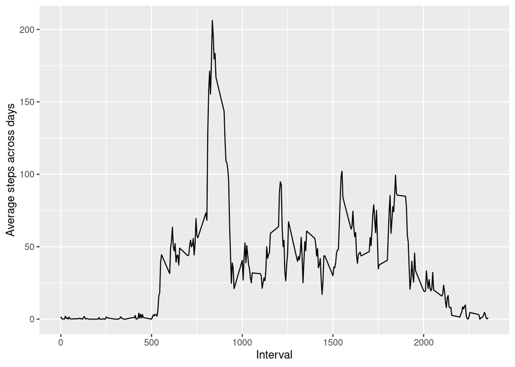

```r
dfm_interval <- dfm %>%
    group_by(interval) %>%
    summarise(avgsteps = mean(steps, na.rm = TRUE))
qplot(dfm_interval$interval, dfm_interval$avgsteps, geom="line",
      xlab="Interval", ylab="Average steps across days")
```

In order to find the interval with the maximum number of average steps we use the function `which.max()`. This function gives us the index of the maximum value. We can then use the index to get the interval.

```r
dfm_interval$interval[which.max(dfm_interval$avgsteps)]
```

```
## [1] 835
```

## Imputing missing values

To calculate the missing values we apply the `is.na()` function and then take the `sum()`, as R interprets `TRUE` as 1 and `FALSE` as 0.

```r
sum(is.na(dfm$steps))
```

```
## [1] 2304
```

In order to fill the missing values, I will use the mean value of interval. Note that the data frame `dfm_interval` already contains all possible filling values. Then, we replace the `NA` with the appropriate value and call the resulting data frame dfnm (nm = no missing).

To impute the missing values, I join the original data frame dfm with dfm_interval. In a second step I replace missing values. Finally, we only select the relevant columns.

```r
dfnm <- left_join(dfm, dfm_interval, by=c("interval"))
dfnm$steps[is.na(dfnm$steps)] <- dfnm$avgsteps[is.na(dfnm$steps)]
dfnm <- dfnm %>%
    select(steps, date, interval)
```

Now, create again the histogram and calculate mean and median of steps taken per day.

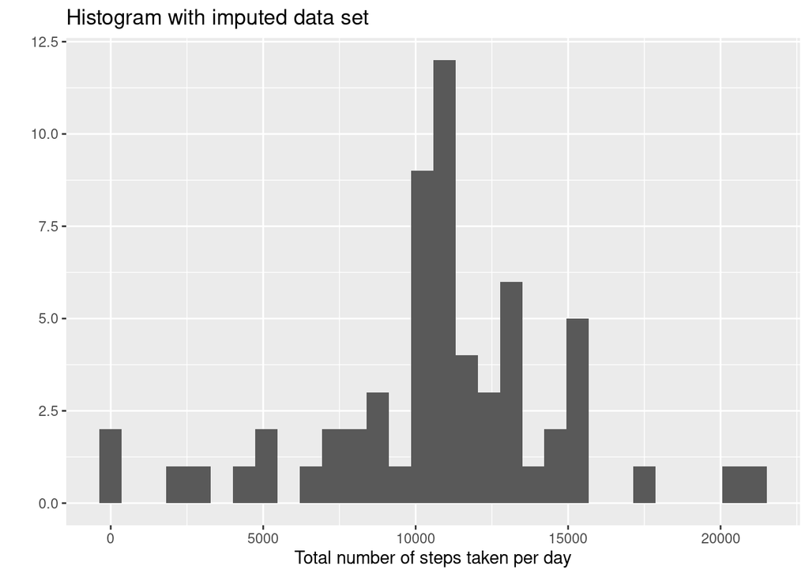

```r
dfnm_daily <- dfnm %>%
    group_by(date) %>%
    summarise(totalsteps = sum(steps))
qplot(dfnm_daily$totalsteps, xlab="Total number of steps taken per day",
      main="Histogram with imputed data set")
```

```r
mean(dfnm_daily$totalsteps)
```

```
## [1] 10766.19
```

```r
median(dfnm_daily$totalsteps)
```

```
## [1] 10766.19
```

The values differ from the original data set, both the mean and median are higher.

## Differences in activity patterns between weekdays and weekends

First we create a new factor variable called weekday

```r
dfnm <- dfnm %>%
    mutate(weekdays = if_else(weekdays(date) == "Saturday" | weekdays(date) == "Sunday", "weekend", "weekday"),
           weekdays = as.factor(weekdays)
           )
dfnm_interval <- dfnm %>%
    group_by(interval, weekdays) %>%
    summarise(avgsteps = mean(steps))
```

On to the plot.

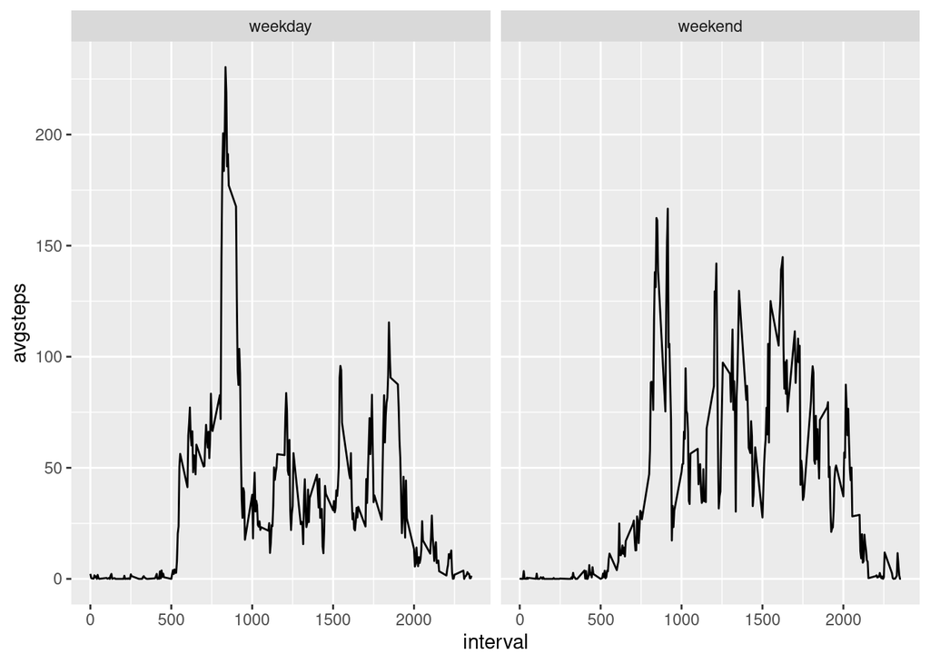

```r
g <- ggplot(data = dfnm_interval, mapping = aes(x=interval, y=avgsteps))
g <- g + geom_line()
g <- g + facet_grid(. ~ weekdays)
g
```